# 算法训练营Day 11

Author

Siru Wu

Published

January 25, 2026

逆波兰式是一种表达式书写方式，运算符写在操作数后面，它也被称为 后缀表达式（Postfix Expression）。

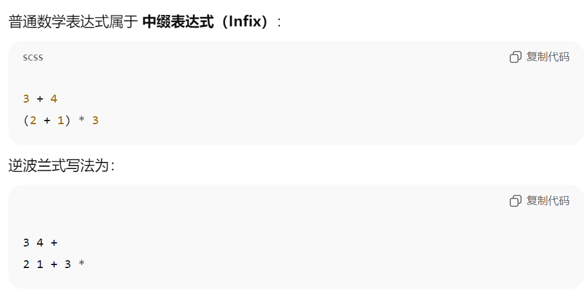

逆波兰式的计算规则：

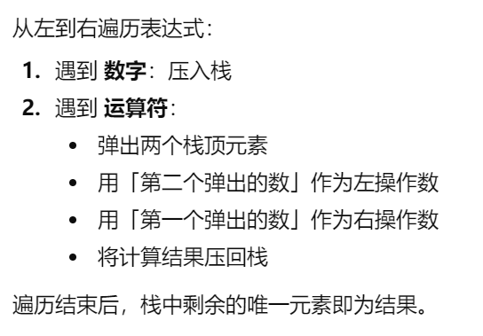

## [150. 逆波兰表达式求值](https://leetcode.cn/problems/evaluate-reverse-polish-notation/description/)

> 给你一个字符串数组 tokens ，表示一个根据 逆波兰表示法 表示的算术表达式。

> 请你计算该表达式。返回一个表示表达式值的整数。

> 注意：
> - 有效的算符为 ‘+’、‘-’、’*’ 和 ‘/’ 。
> - 每个操作数（运算对象）都可以是一个整数或者另一个表达式。
> - 两个整数之间的除法总是 向零截断 。
> - 表达式中不含除零运算。
> - 输入是一个根据逆波兰表示法表示的算术表达式。
> - 答案及所有中间计算结果可以用 32 位 整数表示。

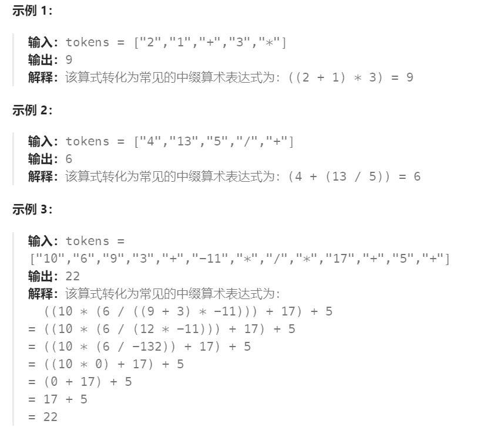

```python
from operator import add, sub, mul

# / 会产生浮点数，不适合整数除法
# // 是整数运算，但对负数是向下取整
# 所以负数除法要用 abs(x)//abs(y) 再手动加符号
def div(x, y):
    return int(x / y) if x * y > 0 else -(abs(x) // abs(y))

class Solution(object):
    op_map = {'+': add, '-': sub, '*': mul, '/': div} # 这里的div就是上面我们自己定义的def div

    def evalRPN(self, tokens):
        stack = []

        for token in tokens:
            if token in self.op_map:
                op2 = stack.pop()
                op1 = stack.pop()
                stack.append(self.op_map[token](op1, op2))
            else:
                stack.append(int(token)) # 这里要写成int(token),
        return stack.pop()
```